# Analysis of Spotify Statistics

Lyn Brush, Huu Phuoc Tran

2026-05-12

## Introduction

The goal of this project is to explore the Spotify Tracks dataset. Analysis of this topic could potentially be useful to musical artists, labels, and music theorists to determine trends across genres and to find what consumers might want.

We will explore the following research questions:

1. How do the descriptive columns (time_signature, tempo, etc) affect the popularity of a track?
2. What is the average of all of the other descriptive variables for each genre?
3. How do mood-related Spotify audio features differ across selected music genres?

## Data

This dataset is from Kaggle, linked here: (https://www.kaggle.com/datasets/maharshipandya/-spotify-tracks-dataset). It contains data on 114 thousand songs over 125 different genres. The data is directly downloadable in the csv format. Here is each column and its purpose:

#### Identification Columns

- track_id: An identification code given by Spotify.
- artists: The names of the artists who performed the track. If there are multiple, they are separated by a “;”.
- album_name: The name of the album the track is on.
- track_name: The name of the track.

While these columns are helpful for finding specific tracks, we didn’t need to use them for our purposes.

#### Descriptive Columns

- popularity: The popularity of a track between 1-100. This is calculated with an algorithm based on the total number of plays and recency of those plays.
- duration_ms: The track length in milliseconds.
- explicit: Boolean value determining whether it has explicit lyrics or not (True = has explicit lyrics).
- key: The key of the track. Numerical values represent different keys in ascending order (0 = C, 1= C#/Db, etc)
- loudness: The loudness of a track in decibels.
- mode: Indicates whether the track is in a major (1) or minor (0) key.
- tempo: The tempo (speed) of the track in beats per minute.
- time_signature: The time signature (beats per measure) of the track. The given number is over 4 (so a value of 3 would translate to 3/4).
- track_genre: The genre of the track.

#### Mood Columns

These columns are on a scale of 0.0 to 1.0, with 1.0 representing a song that represents the column the most. For example, a 0.9 score in danceability would mean the song is very danceable.

- danceability: How suitable a track is for dancing based on elements such as tempo and rhythm.
- energy: How energetic a track is based on intensity, speed, and loudness.
- speechiness: How much spoken word is in the track.
- acousticness: How acoustic (non-electronic) the track is.
- instrumentalness: How little vocal content is included.
- liveness: How confident the data is that this track was recorded live.
- valence: How positive-sounding the track is.

Thankfully, the data was already sufficiently cleaned, so we didn’t need to do any cleaning on our part.

## Results

#### Loading the Dataset

```r
library(readr)
library(tidyverse)
library(dplyr)
library(knitr)
library(kableExtra)
dataset <- read_csv('~/Final/data/dataset.csv')
```

```
## ──────────────────────────────────────────────────────── Delimiter: "," chr
## (5): track_id, artists, album_name, track_name, track_genre dbl (15): ...1,
## popularity, duration_ms, danceability, energy, key, loudness... lgl (1):
## explicit
```

#### How do the descriptive columns (time_signature, tempo, etc) affect the popularity of a track?

##### Correlation between Popularity and Duration:

```r
cor(dataset$popularity, dataset$duration_ms, use = "complete.obs")
```

```
## [1] -0.007101209
```

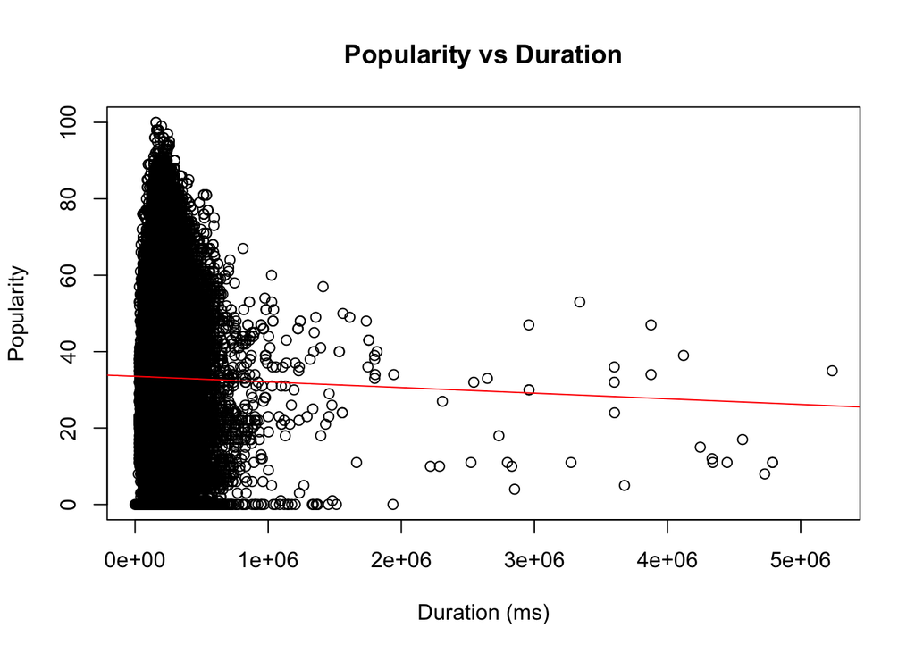

```r
model <- lm(popularity ~ duration_ms, data = dataset)

plot(dataset$duration_ms, dataset$popularity,
     xlab = "Duration (ms)",
     ylab = "Popularity",
     main = "Popularity vs Duration")
abline(model, col = "red")
```

The correlation between the two (-0.007) is basically negligible at such a low number. However, there is a very slight decrease in popularity as songs get longer. This makes sense with the logic of streaming, as longer songs will take longer to stream, and therefore gain streams slower than shorter songs. The graphic supports this, and shows that most songs are clustered around the 3 minute mark, the traditional song length for most genres.

##### Correlation between Popularity and Explicitness

```r
cor(dataset$popularity, ifelse(dataset$explicit, 1, 0), use = "complete.obs")
```

```
## [1] 0.04408176
```

```r
tapply(dataset$popularity, dataset$explicit, mean, na.rm = TRUE)
```

```
##    FALSE     TRUE
## 32.93789 36.45419
```

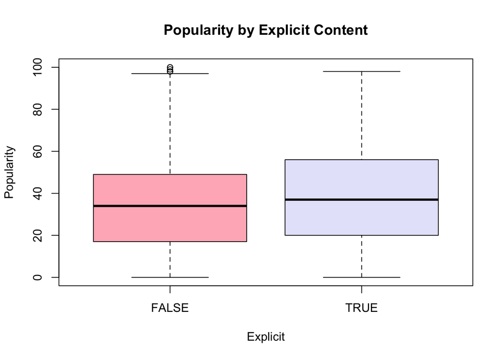

```r
boxplot(popularity ~ explicit, data = dataset,
        xlab = "Explicit",
        ylab = "Popularity",
        col = c("lightpink", "lavender"),
        main = "Popularity by Explicit Content")
```

```r
t.test(popularity ~ explicit, data = dataset)
```

```
##
##  Welch Two Sample t-test
##
## data:  popularity by explicit
## t = -13.755, df = 11301, p-value < 2.2e-16
## alternative hypothesis: true difference in means between group FALSE and group TRUE is not equal to 0
## 95 percent confidence interval:
##  -4.017380 -3.015219
## sample estimates:
## mean in group FALSE  mean in group TRUE
##            32.93789            36.45419
```

With a correlation coefficient of 0.044, explicitness is slightly more relevant to popularity, although it is still not a good indicator. The average popularity score for a non-explicit song is 32.93, and for an explicit song, it’s 36.45. The above boxplot shows the discrepancy between the two; if a song is explicit, it is slightly more likely to have a higher popularity.

##### Correlation between Popularity and Key

```r
dataset$key <- as.factor(dataset$key)

tapply(dataset$popularity, dataset$key, mean, na.rm = TRUE)
```

```
##        0        1        2        3        4        5        6        7
## 32.51994 33.20024 34.37762 33.03165 34.64365 32.93094 33.58553 32.57961
##        8        9       10       11
## 32.95870 32.82357 32.46137 33.88763
```

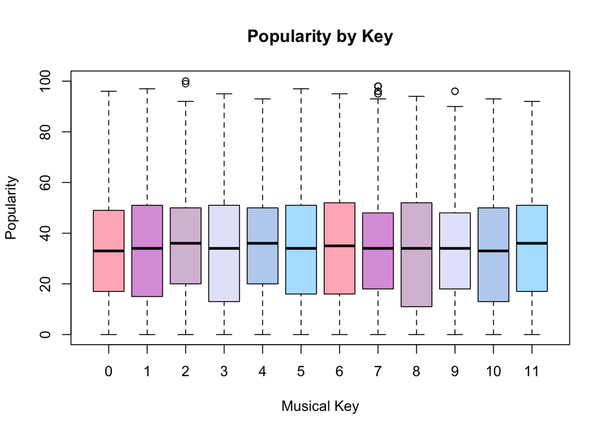

```r
boxplot(popularity ~ key, data = dataset,
        xlab = "Musical Key",
        ylab = "Popularity",
        col = c("lightpink", "plum", "thistle", "lavender", "lightsteelblue2","lightskyblue1"),
        main = "Popularity by Key")
```

While key is displayed using numbers, it’s actually a categorical variable. Because of this, a traditional correlation coefficient can’t be found. Instead, we found the average popularity of each of the 12 keys to determine the most and least popular keys. The most popular is 4, which corresponds to the key of E, with an average popularity score of 34.64; this is followed closely by 2 (D), with a score of 34.37. The least popular key is 10, which corresponds to A#/Bb, and has an average popularity score of 32.46.

##### Correlation between Popularity and Time Signature

```r
dataset$time_signature <- as.factor(dataset$time_signature)

tapply(dataset$popularity, dataset$time_signature, mean, na.rm = TRUE)
```

```
##        0        1        3        4        5
## 36.97546 29.07400 29.69244 33.67248 28.77820
```

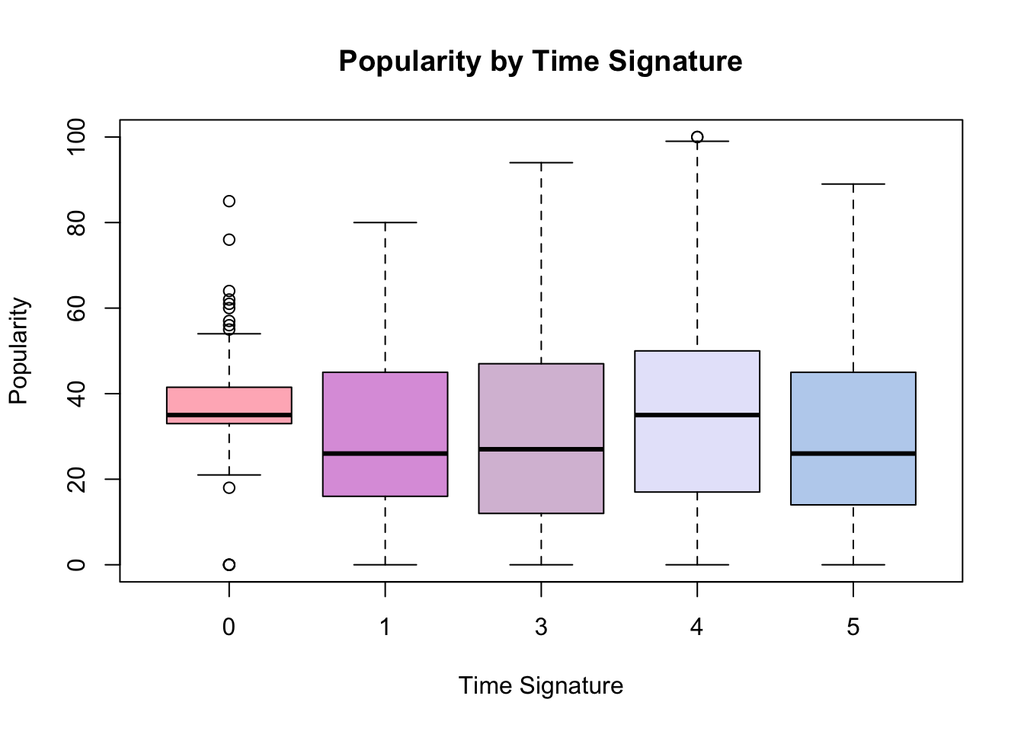

```r
boxplot(popularity ~ time_signature, data = dataset,
        xlab = "Time Signature",
        ylab = "Popularity",
        col = c("lightpink", "plum", "thistle", "lavender", "lightsteelblue2"),
        main = "Popularity by Time Signature")
```

Time signature must be treated like a categorical variable, just like key. According to the boxplot, the most popular time signature is 0/4, with a popularity score of 36.97. It also has the most outliers. This is because 0/4 isn’t really a time signature, and these tracks aren’t songs. One track with 0/4 time signature, “Weißes Rauschen: Schlafmittel”, is a white noise track. The most popular actual time signature is 4/4, with a score of 33.67. This makes sense, since 4/4 is by far the most used time signature across most genres.

##### Correlation between Popularity and Tempo

```r
cor(dataset$popularity[dataset$tempo != 0],
    dataset$tempo[dataset$tempo != 0],
    use = "complete.obs")
```

```
## [1] 0.01437019
```

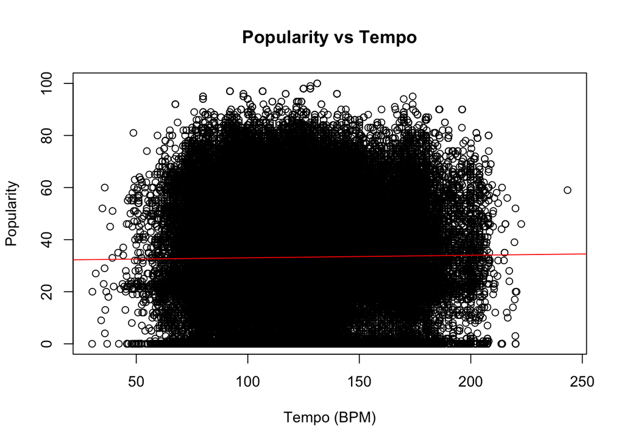

```r
plot(dataset$tempo[dataset$tempo != 0], dataset$popularity[dataset$tempo != 0],
     xlab = "Tempo (BPM)",
     ylab = "Popularity",
     main = "Popularity vs Tempo")

abline(
  lm(popularity ~ tempo, data = dataset),
  col = "red"
)
```

The correlation coefficient between popularity and tempo is 0.014. This is indicates a very small positive correlation, As tempo increases, popularity increases very slightly. This makes sense logically, as people often enjoy upbeat and up-tempo songs that make them feel good.

##### Correlation between Popularity and Mode

```r
cor(dataset$popularity, dataset$mode, use = "complete.obs")
```

```
## [1] -0.01393079
```

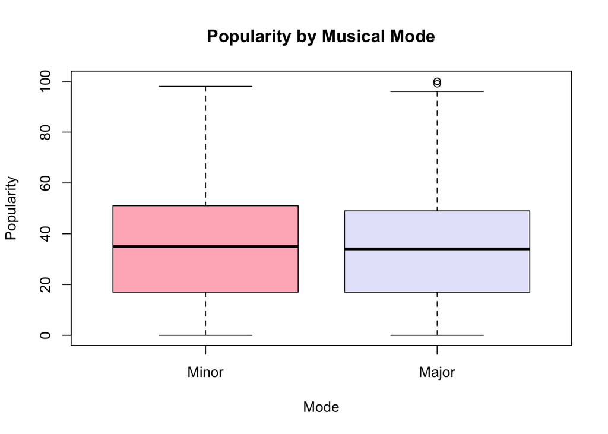

```r
dataset$mode_label <- factor(
  dataset$mode,
  levels = c(0, 1),
  labels = c("Minor", "Major")
)

boxplot(
  popularity ~ mode_label,
  data = dataset,
  col = c("lightpink", "lavender"),
  main = "Popularity by Musical Mode",
  xlab = "Mode",
  ylab = "Popularity"
)
```

The correlation coefficient is -0.013, indicating that there is a very slight negative correlation between mode and popularity. Songs in a major key are slightly less popular overall than songs in a minor key. This is surprising, since the major mode sounds happier, and you’d think people would rather listen to a song with a happier sound. However, making a song in a minor key is more difficult, so it’s possible that they tend to have a better production due to being more challenging for less experienced musicians.

##### Correlation between Popularity and Loudness

```r
cor(dataset$popularity, dataset$loudness, use = "complete.obs")
```

```
## [1] 0.05042304
```

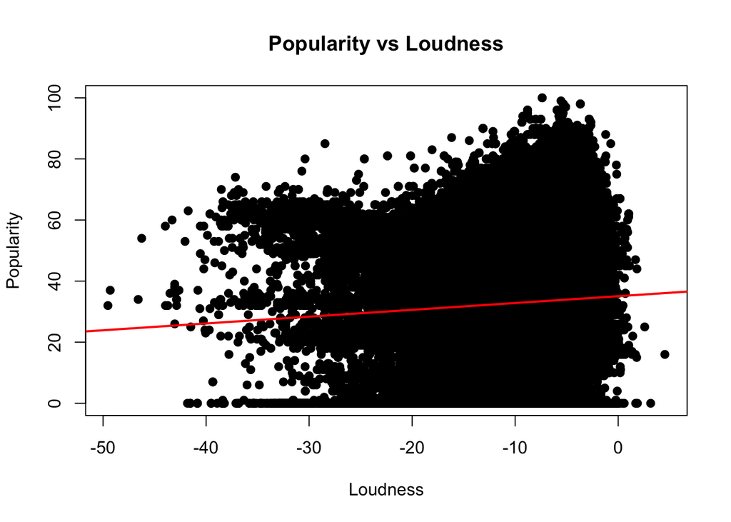

```r
plot(
  dataset$loudness,
  dataset$popularity,
  main = "Popularity vs Loudness",
  xlab = "Loudness",
  ylab = "Popularity",
  pch = 19,
)

abline(
  lm(popularity ~ loudness, data = dataset),
  col = "red",
  lwd = 2
)
```

The correlation coefficient is 0.05, which is the highest of all the correlations so far. While still a slight correlation, songs tend to be more popular as their loudness increases. According to this article (https://pmc.ncbi.nlm.nih.gov/articles/PMC5634808/), music arouses our brain, and loudness intensifies your response to the music. So if you like a song, you’re more likely to want it to be louder to add to your experience.

##### Conclusion

Overall, most of the descriptive variables seemed to have very little effect on the popularity of the song. While there were some slight trends, popularity is likely far more dependant on the popularity of the artist and the perceived quality of the song, both things that are not tracked within this dataset.

#### What is the average of all of the other descriptive variables for each genre?

```r
genres <- c(
  "acoustic",
  "country",
  "rock",
  "jazz",
  "metal",
  "edm",
  "pop",
  "hip-hop",
  "dance",
  "classical"
)

get_mode <- function(x) {
  ux <- unique(x)
  ux[which.max(tabulate(match(x, ux)))]
}

genre_summary <- dataset %>%
  filter(track_genre %in% genres, key != -1) %>%
  group_by(track_genre) %>%
  summarise(
    Tempo = round(mean(tempo, na.rm = TRUE), 1),

    Loudness = round(mean(loudness, na.rm = TRUE), 2),

    Popularity = round(mean(popularity, na.rm = TRUE), 1),

    `Explicit (%)` = round(mean(explicit, na.rm = TRUE) * 100, 1),

    `Duration (min)` = round(mean(duration_ms, na.rm = TRUE) / 60000, 2),

    Mode = ifelse(
      get_mode(mode) == 1,
      "Major",
      "Minor"
    ),

    `Time Sig.` = paste0(get_mode(time_signature), "/4"),

    Key = recode(
      as.character(get_mode(key)),
      "0" = "C",
      "1" = "C#/Db",
      "2" = "D",
      "3" = "D#/Eb",
      "4" = "E",
      "5" = "F",
      "6" = "F#/Gb",
      "7" = "G",
      "8" = "G#/Ab",
      "9" = "A",
      "10" = "A#/Bb",
      "11" = "B"
    ),

    .groups = "drop"
  )

genre_summary %>%
  kable(
    caption = "Summary Statistics by Genre",
    align = "c"
  ) %>%
  kable_styling(
    bootstrap_options = c(
      "striped",
      "hover",
      "condensed",
      "responsive"
    ),
    full_width = FALSE
  )
```

Summary Statistics by Genre

| track_genre | Tempo | Loudness | Popularity | Explicit (%) | Duration (min) | Mode | Time Sig. | Key |
| --- | --- | --- | --- | --- | --- | --- | --- | --- |
| acoustic | 119.0 | -9.45 | 42.5 | 5.2 | 3.58 | Major | 4/4 | C |
| classical | 107.9 | -20.15 | 13.1 | 0.0 | 3.88 | Major | 4/4 | G |
| country | 124.0 | -7.28 | 17.0 | 3.0 | 3.43 | Major | 4/4 | G |
| dance | 120.1 | -5.36 | 22.7 | 17.4 | 3.30 | Major | 4/4 | C#/Db |
| edm | 122.0 | -5.28 | 35.0 | 10.6 | 3.22 | Major | 4/4 | B |
| hip-hop | 116.8 | -5.98 | 37.8 | 31.9 | 3.44 | Minor | 4/4 | C#/Db |
| jazz | 112.6 | -11.58 | 13.6 | 0.3 | 3.17 | Major | 4/4 | C#/Db |
| metal | 127.9 | -5.43 | 43.7 | 14.2 | 4.27 | Major | 4/4 | D |
| pop | 120.9 | -6.95 | 47.6 | 7.4 | 3.68 | Major | 4/4 | F |
| rock | 126.3 | -6.66 | 19.0 | 4.3 | 3.66 | Major | 4/4 | C |

In order to calculate the average descriptive variables of each genre, we have to assemble a list of diverse genres that somewhat represent the full list of 125. Then, we can create a table to view the averages for each of the descriptive variables.